# Project1 R code

Ziqian Wu

14/08/2021

load library

```r
library(dataPreparation)
library(fitdistrplus)
library(speedglm)
library(performance)
library(cvms)
library(broom)
library(tibble)
library(dplyr)
library(sf)
library(curl)
library(tmap)
library(tmaptools)
```

load data

```r
data = read.csv("preprocessed_data/weather_and_yellow_2015_sample.csv")
```

Try to use gamma regression and linear regression to predict the tip amount factorize the categorical attribute

```r
data$Weather<- factor(data$Weather)

model_cols=c("passenger_count","trip_distance","fare_amount","total_amount",
                "Duration","Weather","tip_amount","Temperature_AVG")
```

split the data into training set and testing set

```r
tip_data<-data[data$tip_amount>0,]
smp_size <- floor(0.8 * nrow(tip_data))

set.seed(123)
train_ind <- sample(seq_len(nrow(tip_data)), size = smp_size)

train <- tip_data[train_ind, model_cols]
test <- tip_data[-train_ind, model_cols]

x<-c("passenger_count","trip_distance","fare_amount","total_amount",
    "Duration","Weather","Temperture_AVG")
```

It is not like a normal distribution, so we need to find the most like distribution

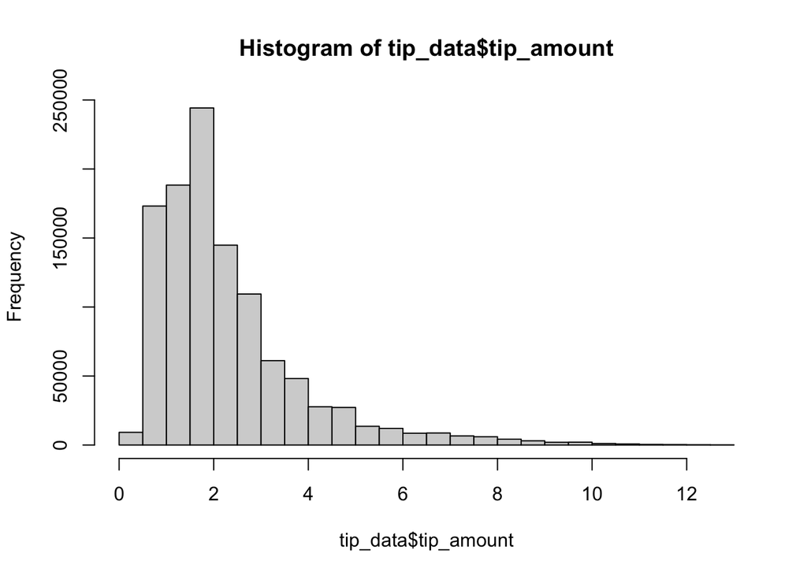

```r
hist(tip_data$tip_amount)
```

Fitting gamma regression model It shows that some features should be dropped off to make the model better

```r
gamma_model = glm(tip_amount~.,family = Gamma(link="log"),data=train)
summary(gamma_model)
```

```
##
## Call:
## glm(formula = tip_amount ~ ., family = Gamma(link = "log"), data = train)
##
## Deviance Residuals:
##     Min       1Q   Median       3Q      Max
## -3.5358  -0.1878   0.0335   0.1759   1.8718
##
## Coefficients:
##                   Estimate Std. Error  t value Pr(>|t|)
## (Intercept)     -2.474e-01  8.636e-04 -286.421  < 2e-16 ***
## passenger_count  7.749e-04  2.049e-04    3.782 0.000155 ***
## trip_distance   -9.516e-02  4.175e-04 -227.936  < 2e-16 ***
## fare_amount     -1.159e-01  2.561e-04 -452.405  < 2e-16 ***
## total_amount     1.691e-01  2.014e-04  839.796  < 2e-16 ***
## Duration         1.031e-06  9.374e-06    0.110 0.912406
## Weathernormal   -6.981e-03  5.710e-04  -12.226  < 2e-16 ***
## Temperature_AVG  1.156e-04  5.527e-05    2.092 0.036477 *
## ---
## Signif. codes:  0 '***' 0.001 '**' 0.01 '*' 0.05 '.' 0.1 ' ' 1
##
## (Dispersion parameter for Gamma family taken to be 0.06614369)
##
##     Null deviance: 301384  on 882365  degrees of freedom
## Residual deviance:  77067  on 882358  degrees of freedom
## AIC: 1584077
##
## Number of Fisher Scoring iterations: 9
```

Find a better gamma regression model via AIC feature selection

```r
gamma_model1 = step(gamma_model,trace=0)
summary(gamma_model1)
```

```
##
## Call:
## glm(formula = tip_amount ~ passenger_count + trip_distance +
##     fare_amount + total_amount + Weather + Temperature_AVG, family = Gamma(link = "log"),
##     data = train)
##
## Deviance Residuals:
##     Min       1Q   Median       3Q      Max
## -3.5358  -0.1878   0.0335   0.1759   1.8719
##
## Coefficients:
##                   Estimate Std. Error  t value Pr(>|t|)
## (Intercept)     -2.474e-01  8.627e-04 -286.738  < 2e-16 ***
## passenger_count  7.751e-04  2.049e-04    3.783 0.000155 ***
## trip_distance   -9.517e-02  4.154e-04 -229.081  < 2e-16 ***
## fare_amount     -1.159e-01  2.547e-04 -454.873  < 2e-16 ***
## total_amount     1.691e-01  2.014e-04  839.853  < 2e-16 ***
## Weathernormal   -6.981e-03  5.710e-04  -12.227  < 2e-16 ***
## Temperature_AVG  1.156e-04  5.527e-05    2.092 0.036472 *
## ---
## Signif. codes:  0 '***' 0.001 '**' 0.01 '*' 0.05 '.' 0.1 ' ' 1
##
## (Dispersion parameter for Gamma family taken to be 0.06614363)
##
##     Null deviance: 301384  on 882365  degrees of freedom
## Residual deviance:  77067  on 882359  degrees of freedom
## AIC: 1584075
##
## Number of Fisher Scoring iterations: 9
```

Evaluate the model after feature selection

```r
r2(gamma_model1)
```

```
## # R2 for Generalized Linear Regression
##   Nagelkerke's R2: 0.776
```

```r
testPred<-predict(gamma_model1,test)
testPred[is.na(testPred)] <- 0

mse_gamma_test<-mean((test$tip_amount - testPred)^2)
print(mse_gamma_test)
```

```
## [1] 3.900452
```

Fitting linear regression model It shows that some features should be dropped off to make the model better

```r
lm_model = lm(tip_amount~.,data=train)
summary(lm_model)
```

```
##
## Call:
## lm(formula = tip_amount ~ ., data = train)
##
## Residuals:
##     Min      1Q  Median      3Q     Max
## -9.8153 -0.2252  0.0421  0.2336  5.7236
##
## Coefficients:
##                   Estimate Std. Error  t value Pr(>|t|)
## (Intercept)     -3.419e-01  1.791e-03 -190.962   <2e-16 ***
## passenger_count  1.449e-04  4.248e-04    0.341   0.7331
## trip_distance   -1.494e-01  8.656e-04 -172.610   <2e-16 ***
## fare_amount     -4.103e-01  5.310e-04 -772.680   <2e-16 ***
## total_amount     5.164e-01  4.175e-04 1236.683   <2e-16 ***
## Duration        -3.936e-05  1.944e-05   -2.025   0.0428 *
## Weathernormal   -1.593e-02  1.184e-03  -13.454   <2e-16 ***
## Temperature_AVG -1.026e-04  1.146e-04   -0.895   0.3708
## ---
## Signif. codes:  0 '***' 0.001 '**' 0.01 '*' 0.05 '.' 0.1 ' ' 1
##
## Residual standard error: 0.5332 on 882358 degrees of freedom
## Multiple R-squared:  0.8829, Adjusted R-squared:  0.8829
## F-statistic: 9.5e+05 on 7 and 882358 DF,  p-value: < 2.2e-16
```

Find a better linear regression model via AIC feature selection

```r
lm_model1 = step(lm_model,trace=0)
summary(lm_model1)
```

```
##
## Call:
## lm(formula = tip_amount ~ trip_distance + fare_amount + total_amount +
##     Duration + Weather, data = train)
##
## Residuals:
##     Min      1Q  Median      3Q     Max
## -9.8155 -0.2252  0.0421  0.2337  5.7237
##
## Coefficients:
##                 Estimate Std. Error  t value Pr(>|t|)
## (Intercept)   -3.418e-01  1.643e-03 -208.002   <2e-16 ***
## trip_distance -1.494e-01  8.655e-04 -172.655   <2e-16 ***
## fare_amount   -4.103e-01  5.309e-04 -772.748   <2e-16 ***
## total_amount   5.164e-01  4.175e-04 1236.712   <2e-16 ***
## Duration      -3.931e-05  1.943e-05   -2.023   0.0431 *
## Weathernormal -1.563e-02  1.136e-03  -13.757   <2e-16 ***
## ---
## Signif. codes:  0 '***' 0.001 '**' 0.01 '*' 0.05 '.' 0.1 ' ' 1
##
## Residual standard error: 0.5332 on 882360 degrees of freedom
## Multiple R-squared:  0.8829, Adjusted R-squared:  0.8829
## F-statistic: 1.33e+06 on 5 and 882360 DF,  p-value: < 2.2e-16
```

evaluate linear regression model

```r
r2(lm_model1)
```

```
## # R2 for Linear Regression
##        R2: 0.883
##   adj. R2: 0.883
```

```r
testPred<-predict(lm_model1,test)
testPred[is.na(testPred)] <- 0

mse_lm_test<-mean((test$tip_amount - testPred)^2)
print(mse_lm_test)
```

```
## [1] 0.2871824
```

By evaluating these two regression models, the linear regression model has better MSE and R-squared score

visualize these two models

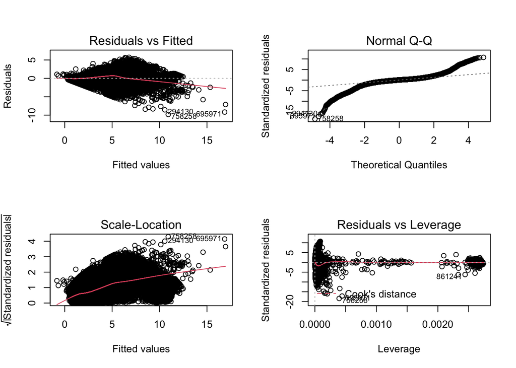

```r
par(mfrow=c(2,2))
plot(lm_model1)
```

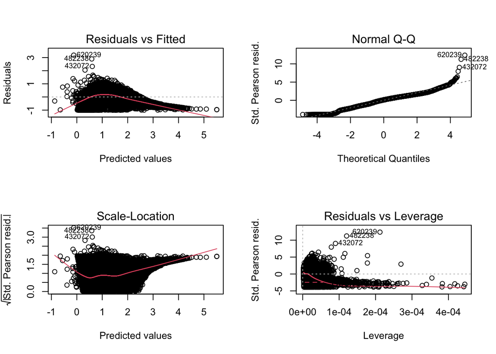

```r
par(mfrow=c(2,2))
plot(gamma_model1)
```

we choose the linear regression model as the final model

```r
x<-c("trip_distance","fare_amount","total_amount","Weather",
     "tip_amount")
final_lm_model=lm(tip_amount~., data=tip_data[,x],
                  subset = -212188-325476-681870)
summary(final_lm_model)
```

```
##
## Call:
## lm(formula = tip_amount ~ ., data = tip_data[, x], subset = -212188 -
##     325476 - 681870)
##
## Residuals:
##      Min       1Q   Median       3Q      Max
## -10.6458  -0.2253   0.0421   0.2337   5.7341
##
## Coefficients:
##                 Estimate Std. Error t value Pr(>|t|)
## (Intercept)   -0.3408191  0.0014682 -232.13   <2e-16 ***
## trip_distance -0.1490752  0.0007700 -193.61   <2e-16 ***
## fare_amount   -0.4093040  0.0004722 -866.86   <2e-16 ***
## total_amount   0.5154982  0.0003734 1380.69   <2e-16 ***
## Weathernormal -0.0159501  0.0010173  -15.68   <2e-16 ***
## ---
## Signif. codes:  0 '***' 0.001 '**' 0.01 '*' 0.05 '.' 0.1 ' ' 1
##
## Residual standard error: 0.5338 on 1102953 degrees of freedom
## Multiple R-squared:  0.8829, Adjusted R-squared:  0.8829
## F-statistic: 2.079e+06 on 4 and 1102953 DF,  p-value: < 2.2e-16
```

model evaluation

```r
r2(final_lm_model)
```

```
## # R2 for Linear Regression
##        R2: 0.883
##   adj. R2: 0.883
```

import 2016 data

```r
yellow_data_2016 = read.csv("preprocessed_data/weather_and_yellow_2016_sample.csv")
```

```r
yellow_data_2016$Weather<- factor(yellow_data_2016$Weather)

key_cols=c("trip_distance","fare_amount","total_amount",
            "Weather","tip_amount")

tip_data_2016<-yellow_data_2016[yellow_data_2016$tip_amount>0,]
test_2016 <- tip_data_2016[, key_cols]
```

predict and evaluate 2016 data

```r
Pred_2016_lm<-predict(final_lm_model,test_2016)
Pred_2016_lm[is.na(Pred_2016_lm)] <- 0

mse_lm_pred_2016<-mean((test_2016$tip_amount - Pred_2016_lm)^2)
print(mse_lm_pred_2016)
```

```
## [1] 0.2845305
```

The MSE of the predicted model is small, which indicates that the model is good.